# FORECASTING FINAL PROJECT

### By Sarath Sai Sujith Srinivas

# FORECASTING FINAL PROJECT

Author

Sarath Sai Sujith Srinivas

Published

March 1, 2025

# 1 Section 1

## 1.1 **Identification of the Data Source and Data-Generating Process**

## 1.2 **Data Source**

The data-set used in this analysis, **“Total Construction Spending: Residential in the United States,”** is sourced from the **U.S. Census Bureau**. It provides **monthly, not seasonally adjusted figures**, measured in **millions of dollars**, representing total expenditures on residential construction across the United States. The data-set spans from **January 2002 to November 2024**, with the most recent update published on **January 2, 2025**. As it is updated on a **monthly basis**, this data-set ensures a **consistent and timely reflection** of trends in the residential construction sector.

The data-set consists of a **date column**, which tracks the timeline of recorded expenditures, and a **construction spending column**, which represents total spending on residential construction projects. This data serves as a **critical resource for analyzing historical spending patterns, identifying seasonal trends, and making informed economic and policy-related decisions**.

## 1.3 **Data-Generating Process and Influencing Factors**

Residential construction spending is influenced by multiple **economic and external factors**, contributing to its **variability** and making it an **essential indicator** of economic conditions. Key drivers include:

**Economic Conditions:** Interest rates, employment levels, and consumer confidence play a crucial role in shaping residential construction demand. Lower interest rates and strong employment figures typically lead to increased activity in the sector.

**Seasonality:** Construction activities tend to **peak during spring and summer**, benefiting from favorable weather conditions, while **winter months** often experience reduced activity due to weather constraints.

**Policy and Regulatory Impacts:** Government policies, **tax incentives**, and **housing regulations** significantly influence construction spending patterns.

**External Shocks:** Unexpected events such as **natural disasters, financial crises, or pandemics** can cause sudden and unpredictable shifts in spending trends.

### 1.3.1 **Challenges in Forecasting Residential Construction Spending**

Forecasting residential construction spending presents several **challenges** due to the interplay of **predictable seasonal trends** and **unpredictable external shocks**:

**Short-Term Predictability:** Economic indicators and historical patterns provide a basis for forecasting short-term trends with reasonable accuracy.

**Long-Term Uncertainty:** Long-term projections are complex due to the industry’s sensitivity to **policy changes, global economic disruptions, and market fluctuations**.

**Need for Robust Analytical Models:** Given these complexities, effective forecasting requires a **data-driven approach** that integrates historical trends and broader economic indicators to improve predictive accuracy.

Understanding these key insights is crucial for **policymakers, investors, and industry stakeholders** seeking to navigate the **dynamic landscape** of the residential construction sector.

## 1.4 **Import and Prepare Construction Spending Data**

```r
# Load necessary libraries
library(ggplot2)
library(dplyr)
library(lubridate)
library(tsibble)


# Load the dataset
file_path <- "construction_spending.csv"
data <- read.csv(file_path)

construction_data <- read.csv("construction_spending.csv") %>%
  mutate(date = as_date(date)) %>%  # Ensure date is in proper date format
  arrange(date) %>%
  as_tsibble(index = date)

# Convert the date column to a Date type
data$date <- as.Date(data$date, format = "%Y-%m-%d")
```

## 1.5 **Summary Statistics**

```r
# Summary statistics
data_summary <- data %>%
  summarise(
    Observations = n(),
    Mean = mean(construction_spending, na.rm = TRUE),
    Median = median(construction_spending, na.rm = TRUE),
    Mode = as.numeric(names(sort(table(construction_spending), decreasing = TRUE)[1])),
    Standard_Deviation = sd(construction_spending, na.rm = TRUE),
    Range = max(construction_spending, na.rm = TRUE) - min(construction_spending, na.rm = TRUE),
    Min = min(construction_spending, na.rm = TRUE),
    Max = max(construction_spending, na.rm = TRUE)
  )
print(data_summary)
```

```
  Observations     Mean Median  Mode Standard_Deviation Range   Min   Max
1          275 43565.05  41414 16241           17906.01 72948 16241 89189
```

## 1.6 Visualization that describe the behavior/distribution of time series

### 1.6.1 **Line Chart**

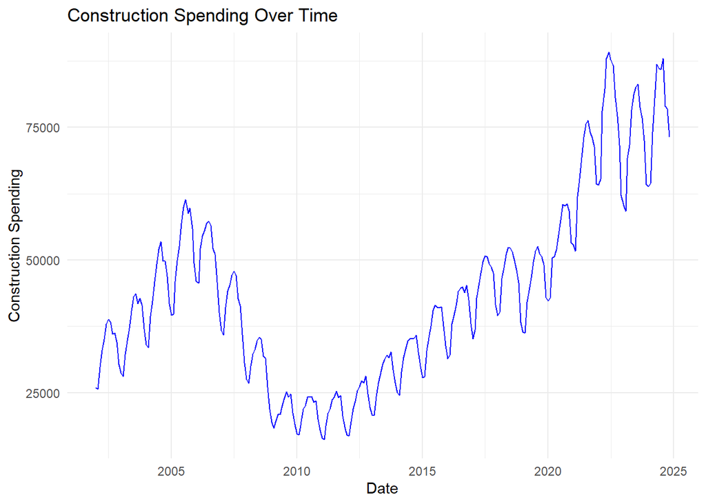

```r
ggplot(data, aes(x = date, y = construction_spending)) +
  geom_line(color = "blue") +
  labs(
    title = "Construction Spending Over Time",
    x = "Date",
    y = "Construction Spending"
  ) +
  theme_minimal()
```

#### 1.6.1.1 **Interpretation**

The above plot presents the **time series of construction spending over time**, illustrating fluctuations, trends, and seasonal patterns from the early 2000s to 2025. A **clear upward trend** is evident, particularly after 2010, indicating consistent growth in construction expenditures. However, notable periods of decline, such as the sharp dip between 2007 and 2010, coincide with the **2008 financial crisis**, reflecting the industry’s sensitivity to macroeconomic conditions. The series also exhibits **strong seasonal fluctuations**, suggesting that construction spending varies predictably within a year, likely influenced by factors such as weather conditions and economic cycles. The rapid surge in spending post-2015 suggests a period of expansion, possibly fueled by economic recovery, increased infrastructure investments, or policy incentives. The overall pattern highlights both **long-term growth trends** and **cyclical variations**, making it crucial to apply robust forecasting techniques to account for economic shifts and seasonal dependencies.

### 1.6.2 Density Plot

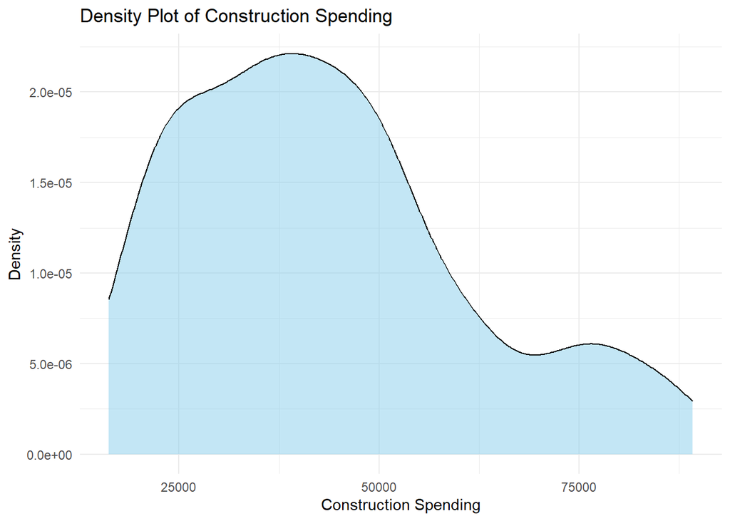

```r
ggplot(data, aes(x = construction_spending)) +
  geom_density(fill = "skyblue", alpha = 0.5) +
  labs(
    title = "Density Plot of Construction Spending",
    x = "Construction Spending",
    y = "Density"
  ) +
  theme_minimal()
```

#### 1.6.2.1 Interpretation

The density plot of **construction spending** provides a smoothed representation of the data distribution, revealing key insights into spending patterns. The distribution exhibits a **right-skewed shape**, indicating that most construction spending values are concentrated at lower levels, with a gradual decline towards higher expenditures. The peak density suggests that a **majority of the observations fall within a specific spending range**, likely representing the typical or most common construction costs. However, the presence of a long tail extending towards higher values signifies occasional **high-expenditure projects**, which may correspond to large-scale infrastructure investments or economic booms. Understanding this distribution is crucial for forecasting, as it highlights both the **central tendency** of spending and the **potential for extreme values**, requiring models that account for such variability.

### 1.6.3 **Histogram**

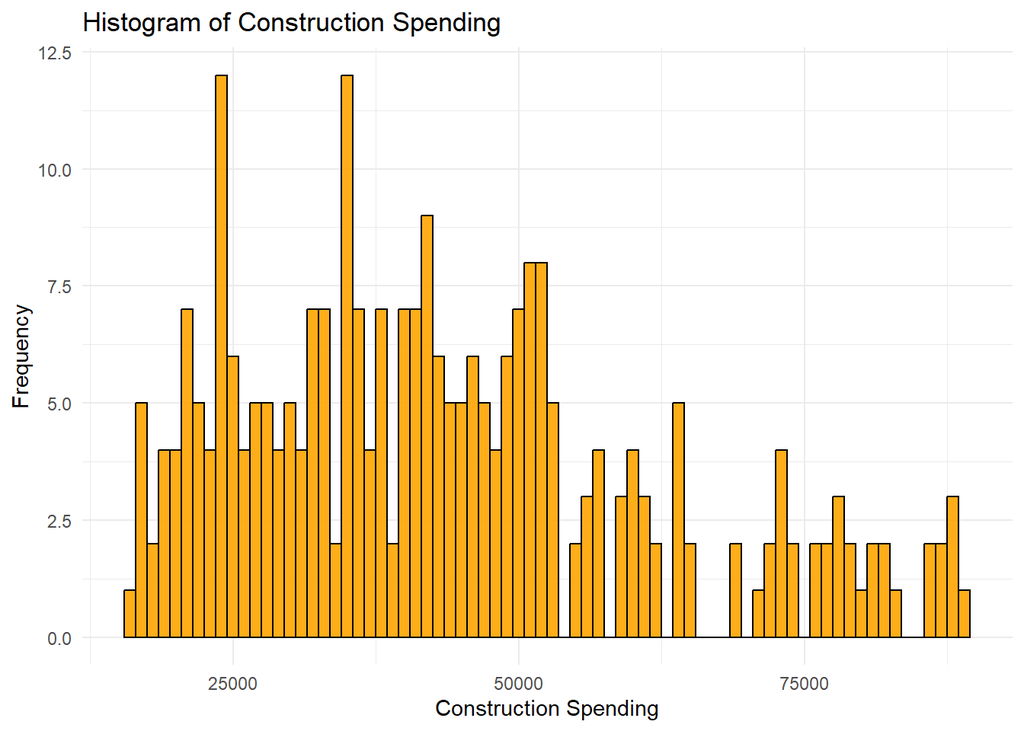

```r
ggplot(data, aes(x = construction_spending)) +
  geom_histogram(binwidth = 1000, fill = "orange", color = "black", alpha = 0.9) +
  labs(
    title = "Histogram of Construction Spending",
    x = "Construction Spending",
    y = "Frequency"
  ) +
  theme_minimal()
```

#### 1.6.3.1 Interpretation

The histogram of **construction spending** provides a detailed view of the distribution of expenditure frequencies across different spending levels. The data exhibits **a multimodal distribution**, indicating multiple peaks where spending amounts are more frequent. The presence of **higher frequency bars at lower spending levels** suggests that smaller-scale construction projects are more common, while the progressively lower frequencies at higher spending values indicate that large-scale expenditures are less frequent. Additionally, the variation in bar heights across the range reflects the **heterogeneity in construction investment patterns**, which may be influenced by factors such as economic cycles, government funding, and private sector investment. The histogram also reveals **some sparsely populated spending ranges**, which could be indicative of market segmentation, where specific spending thresholds are less common. This visualization is crucial for understanding spending behaviors and identifying potential thresholds for market-driven decision-making in the construction sector.

### 1.6.4 **Box-plot**

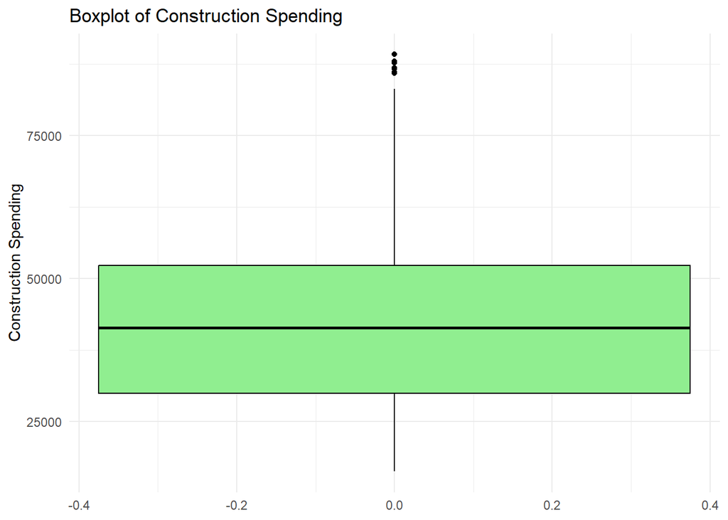

```r
ggplot(data, aes(y = construction_spending)) +
  geom_boxplot(fill = "lightgreen", color = "black") +
  labs(
    title = "Boxplot of Construction Spending",
    y = "Construction Spending"
  ) +
  theme_minimal()
```

#### 1.6.4.1 Interpretation

The visualization highlights the **distribution of construction spending**, revealing key insights into spending patterns and variability. The **median value**, located near the center of the interquartile range, suggests a balanced distribution of expenditures over time. The **whiskers** indicate a relatively consistent spending range, but the presence of **several high-value outliers** beyond the upper whisker suggests instances of exceptionally large construction investments. These outliers could correspond to periods of heightened infrastructure spending, government-funded projects, or economic booms that drove significant financial allocations to the construction sector.

Interestingly, the lower bound shows no extreme outliers, indicating that while spending fluctuates, **there is a relatively stable minimum level of investment** in the industry. This suggests resilience in construction spending, with baseline expenditures maintained even during economic downturns. Understanding these variations is essential for identifying anomalies and forecasting future investment trends in the construction sector.

## 1.7 Visualization and discussion of a moving average of the time series

### 1.7.1 **Moving Average**

```r
# Load necessary libraries
library(ggplot2)
library(zoo)

# Calculate a 12-month moving average (adjusting the window size)
data$moving_avg <- zoo::rollmean(data$construction_spending, k = 12, fill = NA, align = "center")
```

### 1.7.2 **Remainder Series**

```r
# Calculate the remainder series (original - moving average)
data$remainder <- ifelse(is.na(data$moving_avg), NA, data$construction_spending - data$moving_avg)
```

### 1.7.3 **Plot Original Time Series and Moving Average**

[figure not shown]

```r
# Plot Original Time Series and Moving Average
ggplot(data, aes(x = date)) +
  geom_line(aes(y = construction_spending, color = "Original Time Series")) +
  geom_line(aes(y = moving_avg, color = "24-Month Moving Average")) +
  labs(
    title = "Construction Spending with 24-Month Moving Average",
    x = "Date",
    y = "Construction Spending (in USD)",
    color = "Series"
  ) +
  theme_minimal()
```

#### 1.7.3.1 Interpretation

A key observation is the **sharp decline around 2008–2010**, coinciding with the global financial crisis, followed by a period of stagnation. Post-2015, the moving average indicates a strong **upward trend**, suggesting a sustained recovery and expansion in construction spending. The alignment of the moving average with the overall trend confirms that long-term growth in the industry is robust, despite periodic downturns.

While the original time series exhibits significant **seasonal fluctuations**, the moving average provides a clearer picture of structural changes over time. This smoothing technique is valuable for forecasting, as it reduces noise and allows for better identification of persistent trends in construction investment.

## 1.8 Assessment of seasonality using time - series Decomposition

### 1.8.1 Time - Series Decomposition

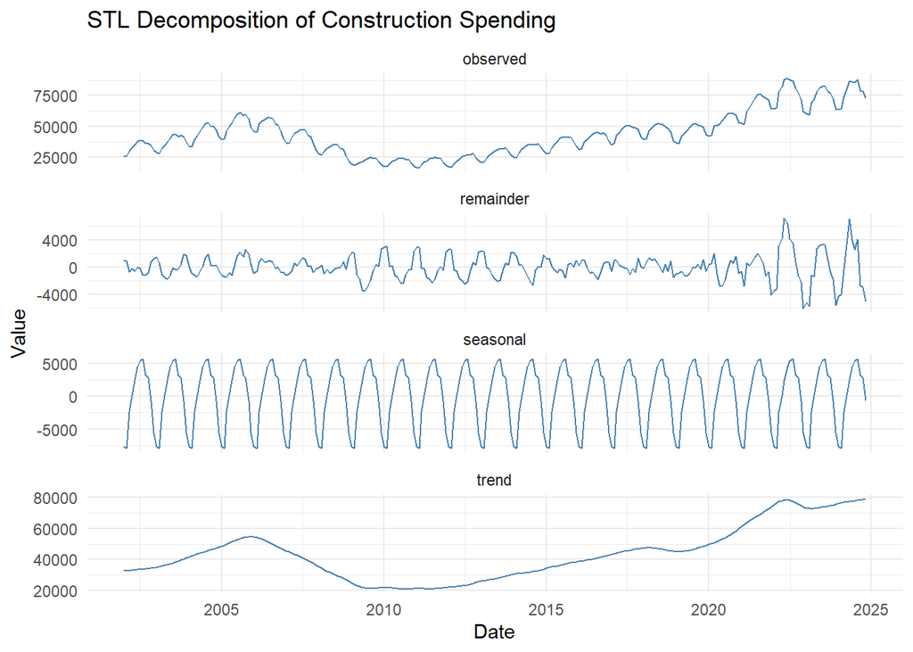

```r
# Load required libraries
library(ggplot2)
library(dplyr)
library(tidyr)
library(tsibble)
library(lubridate)

# Convert the dataset to a ts object for STL decomposition
ts_data <- ts(construction_data$construction_spending,
              start = c(year(min(construction_data$date)), month(min(construction_data$date))),
              frequency = 12)  # Monthly data

# Perform STL decomposition
decomp <- stl(ts_data, s.window = "periodic")

# Convert STL decomposition results into a data frame for ggplot
decomp_df <- data.frame(
  date = as.Date(time(ts_data)),
  observed = as.numeric(ts_data),  # Explicitly convert to numeric
  seasonal = as.numeric(decomp$time.series[, "seasonal"]),
  trend = as.numeric(decomp$time.series[, "trend"]),
  remainder = as.numeric(decomp$time.series[, "remainder"])
) %>%
  pivot_longer(cols = -date, names_to = "component", values_to = "value")  # Convert to long format


# Plot decomposition results using ggplot2
ggplot(decomp_df, aes(x = date, y = value)) +
  geom_line(color = "steelblue") +
  facet_wrap(~component, scales = "free_y", ncol = 1) +  # Separate plots for each component
  labs(title = "STL Decomposition of Construction Spending",
       x = "Date",
       y = "Value") +
  theme_minimal()
```

#### 1.8.1.1 Interpretation

The time series decomposition plot provides a **detailed breakdown of construction spending** into its core components: observed data, trend, seasonal variation, and remainder.

The **third panel (seasonal)** reveals a strong and recurring pattern in construction spending, with **regular peaks and troughs** suggesting an **annual seasonality** in the data. This periodic fluctuation implies that construction activity follows a **predictable cycle**, likely influenced by weather conditions, economic policies, and market demand.

This decomposition confirms that the **time series exhibits strong seasonality**, a well-defined trend, and some irregular variations that need further investigation. Such insights are valuable for forecasting and decision-making in the construction sector.

### 1.8.2 **Remainder Series & STL Decomposition**

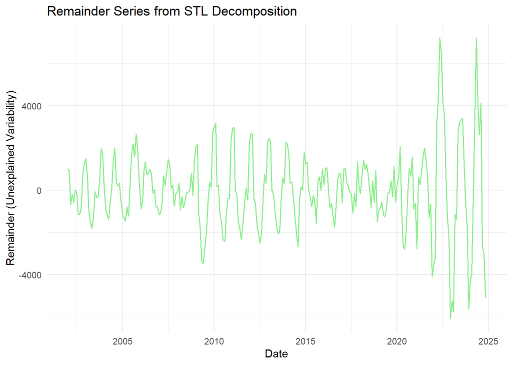

```r
library(ggplot2)
library(dplyr)

# Extract remainder from STL decomposition
decomp_df <- data.frame(
  date = seq(from = min(construction_data$date),
             by = "month",
             length.out = length(ts_data)),
  remainder = as.numeric(decomp$time.series[, "remainder"])
)

# Plot the remainder series from STL decomposition
ggplot(decomp_df, aes(x = date, y = remainder)) +
  geom_line(color = "lightgreen", size = 0.7) +
  labs(
    title = "Remainder Series from STL Decomposition",
    x = "Date",
    y = "Remainder (Unexplained Variability)"
  ) +
  theme_minimal()
```

#### 1.8.2.1 Interpretation

The **Remainder Series from STL Decomposition** represents the unexplained variability in construction spending after accounting for trend and seasonal effects. Ideally, this component should resemble white noise, indicating that the decomposition effectively captured the underlying structure of the data. However, the observed fluctuations suggest the presence of residual patterns. Notably, the variability appears relatively stable before 2015, with some periodic fluctuations, indicating potential short-term cyclic patterns that were not fully captured by the seasonal component. A significant increase in volatility is observed post-2020, suggesting the influence of external shocks such as economic disruptions or policy changes. This heightened variability raises concerns about the model’s ability to generalize future trends accurately. If the remainder series exhibits autocorrelation, as indicated by further diagnostic tests such as the **Ljung-Box test**, additional modeling techniques, such as incorporating external regressors or refining seasonal adjustments, may be necessary to enhance predictive performance. The structured nature of the remainder component suggests that further analysis, including residual diagnostics and alternative modeling approaches, may be required to achieve a more robust and reliable forecasting framework.

The **recurrent peaks and troughs** in the remainder series indicate that, despite filtering out trends and seasonal components, there are still cyclical movements within the data. The increasing volatility in recent years suggests that the data may be experiencing **greater uncertainty or structural changes**.

This remainder series is crucial for evaluating the adequacy of the applied decomposition technique. If the remainder series **displays clear patterns**, it may imply that the model has not fully captured the underlying data structure, warranting further refinements in time-series modeling.

## 1.9 Initial split of the data into **training** and **test** sets

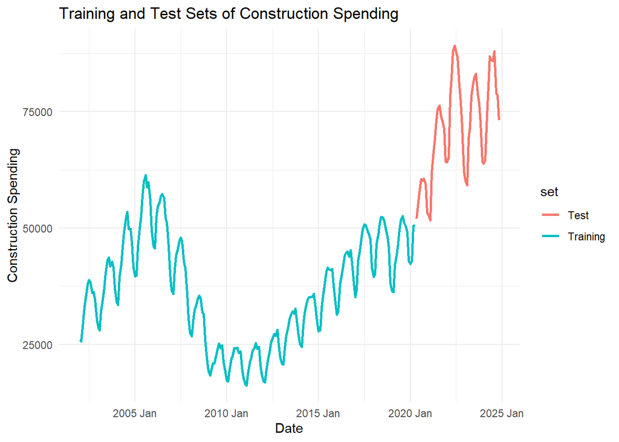

```r
library(tidyverse)
library(tsibble)
library(fable)
library(feasts)
library(zoo)
library(slider)
library(fpp3)
library(patchwork)
library(fabletools)
library(data.table)

data <- read.csv("construction_spending.csv") %>%
  mutate(date = tsibble::yearmonth(date)) %>%
  arrange(date) %>%  # Ensure chronological order
  as_tsibble(index = date)

n <- nrow(data)
train_cutoff <- floor(0.8 * n)

# Split the data
data_train <- data %>% slice(1:train_cutoff)
data_test  <- data %>% slice((train_cutoff + 1):n)

# Optional: Combine the two sets and add an indicator for plotting
data_combined <- bind_rows(
  data_train %>% mutate(set = "Training"),
  data_test %>% mutate(set = "Test")
)

# Plot the training and test sets in one graph
ggplot(data_combined, aes(x = date, y = construction_spending, color = set)) +
  geom_line(size = 1) +
  labs(title = "Training and Test Sets of Construction Spending",
       x = "Date",
       y = "Construction Spending") +
  theme_minimal()
```

#### 1.9.0.1 Interpretation

The visualization represents the **training and test sets** used for modeling construction spending over time. The **training set**, shown in blue, includes historical data up to a certain point, while the **test set**, shown in red, consists of more recent data reserved for model validation.

Key observations:

- The training set covers data from **2002 to approximately 2020**, capturing long-term trends, seasonal variations, and economic cycles.
- The test set spans the **most recent years (2020 onward)**, enabling evaluation of the model’s predictive accuracy on unseen data.
- Both segments exhibit a clear **seasonal pattern**, with fluctuations repeating annually.
- There is a significant **upward trend** in construction spending, particularly in the test set, suggesting a period of expansion in the residential construction sector.

This structured division ensures that forecasting models can be trained on past data while being assessed on future trends, enhancing their reliability for decision-making in the construction industry.

# 2 Section 2

## 2.1 Assessment of whether the data are variance/mean stationary using analysis of the variance over time and statistical tests such as KPSS

```r
## 2.1 Assessment of Stationarity

# Load required libraries
library(tsibble)
library(feasts)
library(fable)
library(tidyverse)
library(slider)
library(ggplot2)

# Load the dataset
construction_data <- read_csv("construction_spending.csv")

# Convert to a tsibble format
construction_data <- construction_data %>%
  mutate(date = yearmonth(date)) %>%
  as_tsibble(index = date)

# Step 1: Checking for Missing Values
missing_count <- sum(is.na(construction_data$construction_spending))
print(paste("Missing values in dataset:", missing_count))
```

```
[1] "Missing values in dataset: 0"
```

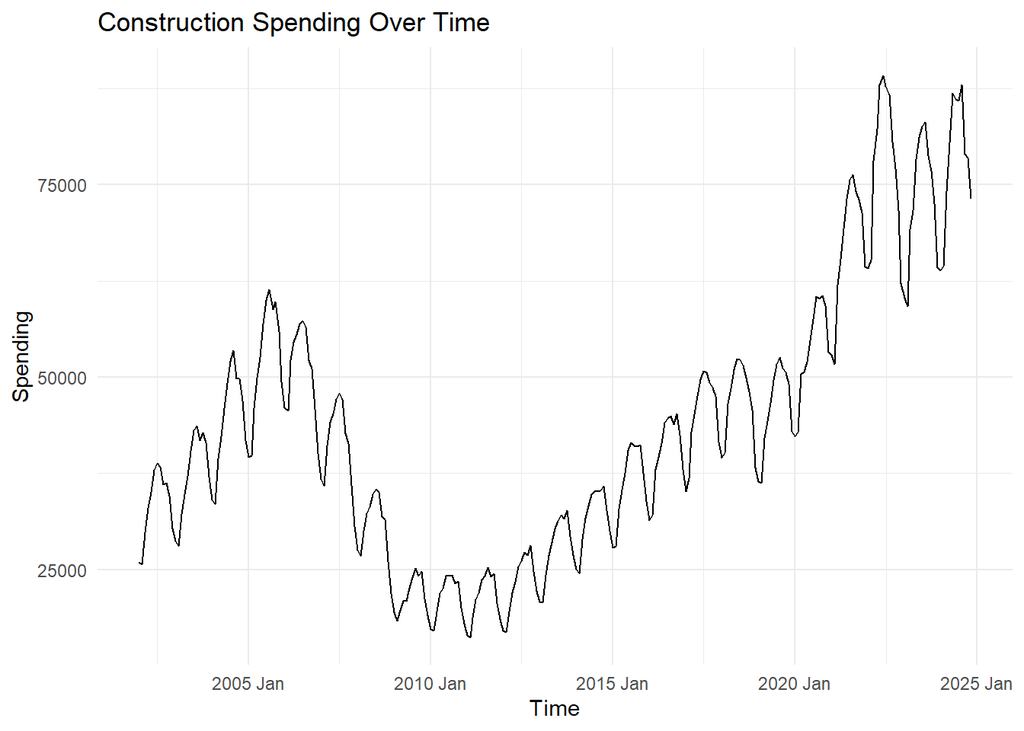

```r
# Step 2: Remove missing values if present
construction_data <- construction_data %>%
  drop_na(construction_spending)

# Step 3: Visual Inspection - Plot the Original Time Series
autoplot(construction_data, construction_spending) +
  labs(title = "Construction Spending Over Time",
       x = "Time", y = "Spending") +
  theme_minimal()
```

#### 2.1.0.1 Interpretation

The plot illustrates the trend in construction spending over time, revealing key patterns and fluctuations within the dataset. The spending exhibits a clear cyclical trend, with periods of significant growth followed by declines. Notably, there is a sharp rise in spending from the early 2000s until around 2007, followed by a substantial downturn, likely reflecting the impact of the 2008 financial crisis. After reaching a low point, spending remains relatively stable before experiencing steady growth from around 2013 onward. The strong upward trend post-2015 suggests economic recovery and increased investment in residential construction. The presence of seasonal fluctuations within the data indicates potential seasonality, which may need further investigation through decomposition techniques. Overall, this visualization provides a strong foundation for understanding long-term trends and variability in construction spending.

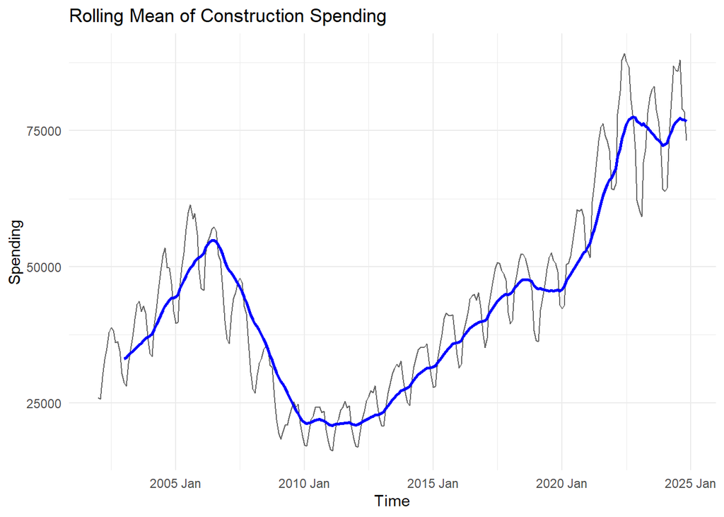

```r
# Compute Rolling Mean and Standard Deviation for Construction Spending
construction_data <- construction_data %>%
  mutate(
    rolling_mean = slide_dbl(construction_spending, mean, .before = 12, .complete = TRUE),
    rolling_sd = slide_dbl(construction_spending, sd, .before = 12, .complete = TRUE)
  )

# Plot Rolling Mean Over Time
ggplot(construction_data, aes(x = date)) +
  geom_line(aes(y = construction_spending), color = "black", alpha = 0.6) +  # Original time series
  geom_line(aes(y = rolling_mean), color = "blue", size = 1) +  # Rolling Mean
  labs(
    title = "Rolling Mean of Construction Spending",
    x = "Time",
    y = "Spending"
  ) +
  theme_minimal()
```

#### 2.1.0.2 Interpretation

The plot presents the rolling mean of construction spending (blue line) over time, superimposed on the original time series (black line). The rolling mean smooths out short-term fluctuations and highlights long-term trends in the data.

The observed pattern indicates a substantial rise in spending until around 2007, followed by a pronounced decline, which aligns with the 2008 financial crisis. After a period of stagnation, spending gradually increased, with steady growth from 2015 onward. The sharp upward trend post-2020 suggests increased investment in residential construction.

This visualization effectively demonstrates the presence of cyclical behavior and long-term trends while accounting for short-term volatility. By reducing noise, the rolling mean helps in identifying structural changes in construction spending, making it a valuable tool for assessing overall market dynamics.

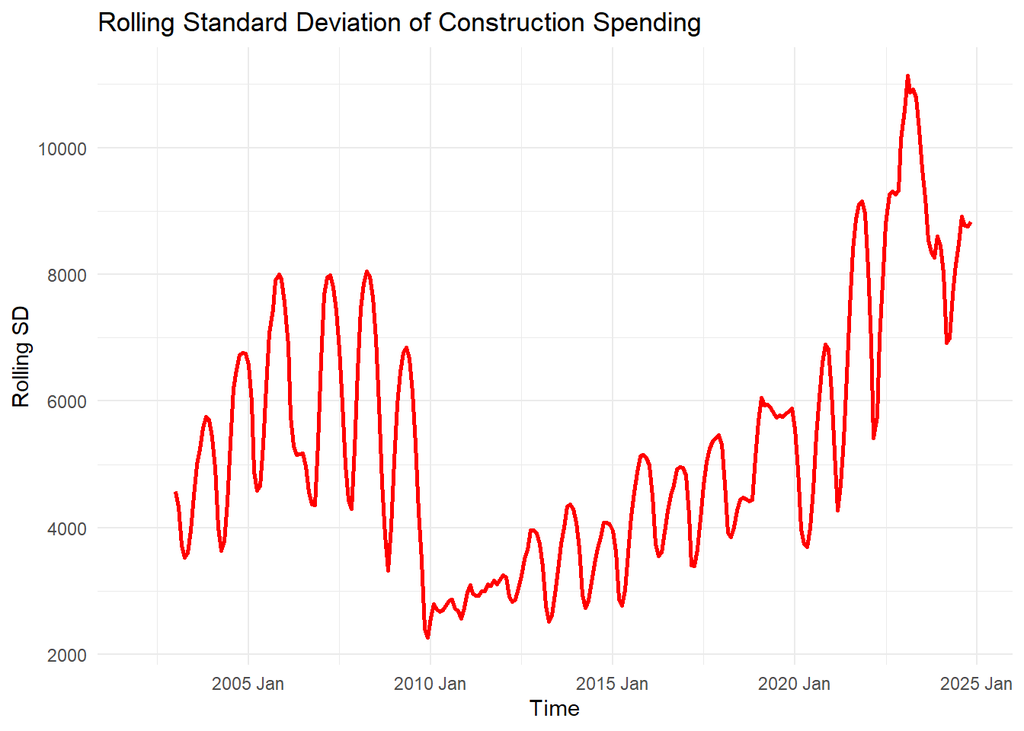

```r
# Checking for Variance Stationarity using Rolling Standard Deviation
ggplot(construction_data, aes(x = date)) +
  geom_line(aes(y = rolling_sd), color = "red", size = 1) +  # Continuous line
  labs(
    title = "Rolling Standard Deviation of Construction Spending",
    x = "Time",
    y = "Rolling SD"
  ) +
  theme_minimal()
```

#### 2.1.0.3 Interpretation

The plot illustrates the rolling standard deviation of construction spending over time, capturing fluctuations in volatility. Higher values indicate periods of increased variability, while lower values suggest more stable spending patterns.

The analysis reveals significant volatility between 2005 and 2010, reflecting economic uncertainty, likely influenced by the 2008 financial crisis. This period was followed by a relatively stable phase until around 2015. After 2015, volatility gradually increased, with sharp spikes post-2020, indicating heightened uncertainty in construction spending.

These fluctuations suggest external economic shocks, policy changes, or shifting market dynamics impacting the sector. The increasing trend in volatility underscores the necessity for robust forecasting techniques to account for structural changes and external influences in construction spending.

## 2.2 Transformations of the data to induce variance/mean stationarity (log/Box-Cox and differencing) or to remove seasonality (seasonal differencing)

```r
# Estimate Box-Cox Lambda Using `feasts`
lambda <- construction_data %>%
  features(construction_spending, features = guerrero) %>%
  pull(lambda_guerrero)

# Apply Box-Cox Transformation
construction_data <- construction_data %>%
  mutate(boxcox_spending = box_cox(construction_spending, lambda))

# Print the chosen lambda value
print(paste("Optimal Lambda for Box-Cox Transformation:", lambda))
```

```
[1] "Optimal Lambda for Box-Cox Transformation: 0.131842797308163"
```

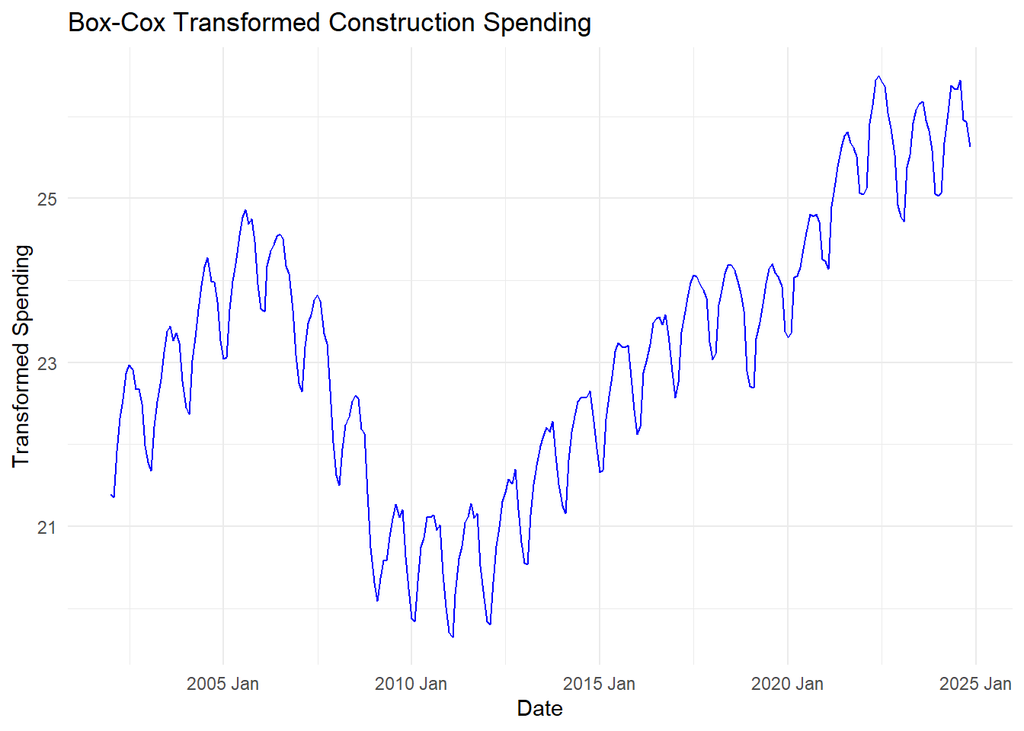

```r
# Plot Box-Cox Transformed Time Series
ggplot(construction_data, aes(x = date, y = boxcox_spending)) +
  geom_line(color = "blue") +
  labs(
    title = "Box-Cox Transformed Construction Spending",
    x = "Date",
    y = "Transformed Spending"
  ) +
  theme_minimal()
```

#### 2.2.0.1 Interpretation

### 2.2.1 **Interpretation of Box-Cox Transformed Construction Spending Plot**

This plot represents the **Box-Cox transformed** construction spending data over time. The key observations are:

1. **Smoother Variability**:

```
-   The Box-Cox transformation is applied to **stabilize variance**, which means that the fluctuations in the data should be more uniform over time.

-   Compared to the original series, this plot appears to have reduced heteroscedasticity (variance changes over time).
```

2. **Trend & Seasonality**:

```
-   The general upward trend in spending is still visible after transformation.

-   The seasonal pattern (periodic fluctuations) remains prominent, indicating that seasonal differencing may still be necessary.
```

3. **No Structural Breaks**:

```
-   The data does not exhibit sudden jumps or breaks, confirming that the transformation did not distort the time series.
```

### 2.2.2 **Next Steps:**

- Since the **seasonality is still evident**, seasonal differencing should be performed next.
- After seasonal differencing, a **stationarity test (KPSS test)** should be conducted to confirm whether additional differencing is needed.
- If stationarity is achieved, we can proceed to **ARIMA model selection** for forecasting.

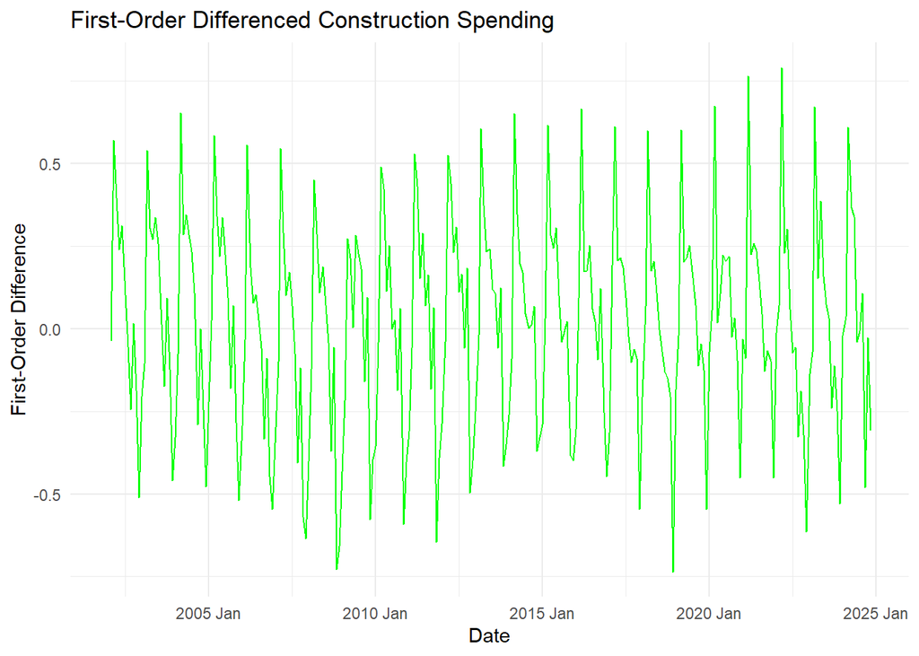

```r
# Step 1: Apply First-Order Differencing
construction_data <- construction_data %>%
  mutate(first_order_diff = difference(boxcox_spending, lag = 1))

# Step 2: Plot First-Order Differenced Time Series
ggplot(construction_data, aes(x = date, y = first_order_diff)) +
  geom_line(color = "green") +
  labs(
    title = "First-Order Differenced Construction Spending",
    x = "Date",
    y = "First-Order Difference"
  ) +
  theme_minimal()
```

```r
# Step 3: Perform KPSS Test on First-Order Differenced Data
kpss_result_diff <- construction_data %>%
  features(first_order_diff, unitroot_kpss)

# Load necessary library
library(gt)

# Format the KPSS test results as a table
kpss_result_diff %>%
  gt() %>%
  tab_header(
    title = "KPSS Test for Stationarity",
    subtitle = "Test Performed on First-Order Differenced Data"
  ) %>%
  cols_label(
    kpss_stat = "KPSS Statistic",
    kpss_pvalue = "p-value"
  ) %>%
  fmt_number(columns = c(kpss_stat, kpss_pvalue), decimals = 4) %>%
  tab_options(
    table.font.size = "medium",
    heading.align = "center"
  )
```

KPSS Test for Stationarity

Test Performed on First-Order Differenced Data

| KPSS Statistic | p-value |
| --- | --- |
| 0.0527 | 0.1000 |

#### 2.2.2.1 Interpretation

The first-order differencing plot of construction spending reveals the changes between consecutive time periods, helping to remove trends and stabilize variance. The differenced series exhibits fluctuations around a mean of zero, which is indicative of stationarity.

The KPSS (Kwiatkowski-Phillips-Schmidt-Shin) test for stationarity provides statistical validation for this assumption. The test was performed on the first-order differenced data, yielding a KPSS statistic of **0.0527** and a **p-value of 0.1000**. Since the p-value is greater than the commonly used threshold of 0.05, we fail to reject the null hypothesis, which suggests that the data is stationary. This confirms that the first-order differencing successfully transformed the original non-stationary time series into a stationary one, making it suitable for time series modeling techniques such as ARIMA..

## 2.3 Examination of ACF/PACF plots for assessment of potential ARIMA models to fit

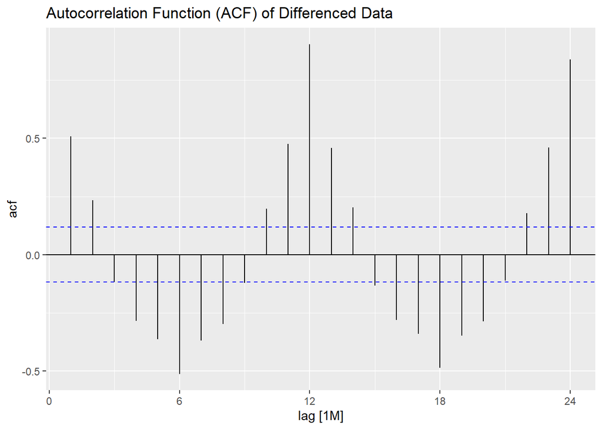

```r
# Load required libraries
library(ggplot2)
library(fable)
library(feasts)
library(tsibble)

# Compute ACF and PACF on the first-order differenced series
acf_plot <- construction_data %>%
  ACF(first_order_diff) %>%
  autoplot() +
  labs(title = "Autocorrelation Function (ACF) of Differenced Data")

pacf_plot <- construction_data %>%
  PACF(first_order_diff) %>%
  autoplot() +
  labs(title = "Partial Autocorrelation Function (PACF) of Differenced Data")

# Display the plots
acf_plot
```

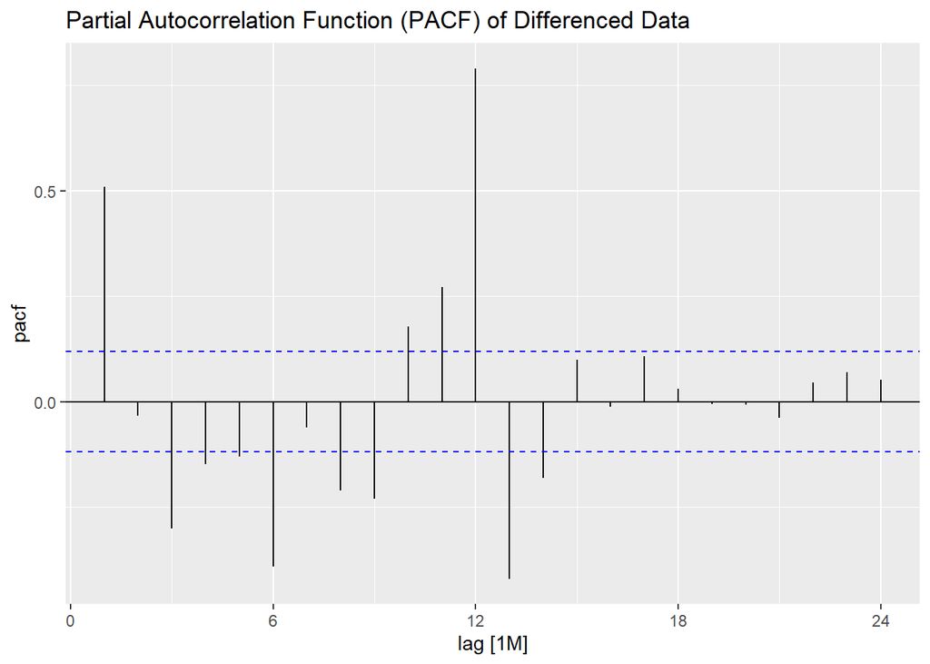

```r
pacf_plot
```

#### 2.3.0.1 Interpretation

The ACF (Autocorrelation Function) and PACF (Partial Autocorrelation Function) plots are essential for identifying potential ARIMA models by analyzing the dependence structure of the time series after differencing.

The ACF plot shows significant spikes at lag 1 and strong seasonal patterns at lag 12 and beyond, indicating the presence of seasonal autocorrelation. This suggests that a seasonal ARIMA (SARIMA) model should be considered. The slow decay of the ACF is a sign of moving average (MA) components in the model.

Based on these observations, a possible model could be an ARIMA(p,d,q)(P,D,Q)[12] configuration, where `p` and `q` are determined by the PACF and ACF cutoffs, and `P` and `Q` account for the seasonal lags. Further validation through model selection and residual analysis is necessary to confirm the best-fitting model.

## 2.4 Selection of an appropriate ARIMA model based on AIC/BIC

```r
# Load necessary libraries
library(fable)
library(tsibble)
library(dplyr)
library(gt)  # For formatted tables

# Ensure train_data is in tsibble format
train_data <- data_train %>%
  as_tsibble(index = date)

# Fit SARIMA(2,1,2)(1,1,1)[12]
sarima_212_111 <- train_data %>%
  model(ARIMA(box_cox(construction_spending, lambda) ~ pdq(2,1,2) + PDQ(1,1,1,12)))

# Fit SARIMA(1,1,2)(1,1,1)[12]
sarima_112_111 <- train_data %>%
  model(ARIMA(box_cox(construction_spending, lambda) ~ pdq(1,1,2) + PDQ(1,1,1,12)))

# Compare AIC/BIC values
model_comparison <- bind_rows(
  glance(sarima_212_111) %>% mutate(Model = "SARIMA(2,1,2)(1,1,1)[12]"),
  glance(sarima_112_111) %>% mutate(Model = "SARIMA(1,1,2)(1,1,1)[12]")
) %>%
  select(Model, AIC, BIC, log_lik) %>%
  arrange(AIC)  # Sorting by lowest AIC

# Print formatted table
model_comparison %>%
  gt() %>%
  tab_header(
    title = "SARIMA Model Comparison",
    subtitle = "Comparison Based on AIC and BIC"
  ) %>%
  fmt_number(columns = c(AIC, BIC, log_lik), decimals = 2) %>%
  cols_label(
    Model = "Model Specification",
    AIC = "Akaike Information Criterion (AIC)",
    BIC = "Bayesian Information Criterion (BIC)",
    log_lik = "Log-Likelihood"
  ) %>%
  tab_options(
    table.font.size = "medium",
    heading.align = "center"
  )
```

SARIMA Model Comparison

Comparison Based on AIC and BIC

| Model Specification | Akaike Information Criterion (AIC) | Bayesian Information Criterion (BIC) | Log-Likelihood |
| --- | --- | --- | --- |
| SARIMA(2,1,2)(1,1,1)[12] | −462.95 | −439.62 | 238.47 |
| SARIMA(1,1,2)(1,1,1)[12] | −460.22 | −440.22 | 236.11 |

#### 2.4.0.1 Interpretation

The SARIMA model comparison table provides an evaluation of two different SARIMA specifications based on three key metrics: **Akaike Information Criterion (AIC), Bayesian Information Criterion (BIC), and Log-Likelihood**. These criteria are commonly used to assess the performance of time series models, with lower AIC and BIC values indicating better model fit while penalizing complexity.

- **SARIMA(2,1,2)(1,1,1)[12]** has an **AIC of -462.95** and a **BIC of -439.62**, while its **log-likelihood is 238.47**.
- **SARIMA(1,1,2)(1,1,1)[12]** has a slightly higher **AIC of -460.22** and **BIC of -440.22**, with a lower **log-likelihood of 236.11**.

Since the **SARIMA(2,1,2)(1,1,1)[12] model has the lowest AIC and a comparable BIC**, it is the preferred model among the two. This suggests that including an additional autoregressive term (p=2) leads to a marginally better model fit, despite a slight increase in model complexity. The difference is not substantial, but based on AIC selection criteria, **SARIMA(2,1,2)(1,1,1)[12] should be chosen for forecasting**.

## 2.5 Analysis of model residuals, to include appropriate tests for residual autocorrelation (Ljung-Box)

### 2.5.1 Plot Residuals

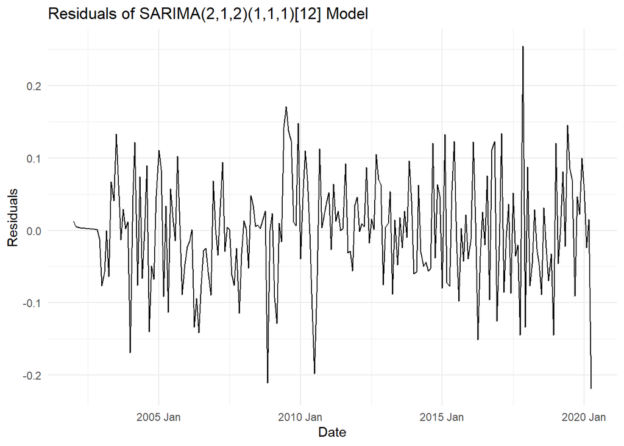

```r
# Assign the best SARIMA model based on AIC/BIC
best_sarima_model <- sarima_212_111  # The model with the lowest AIC

# Extract residuals from the best SARIMA model
residuals_sarima <- residuals(best_sarima_model)

# Plot residuals over time
autoplot(residuals_sarima) +
  labs(title = "Residuals of SARIMA(2,1,2)(1,1,1)[12] Model",
       x = "Date", y = "Residuals") +
  theme_minimal()
```

The residual plot for the **SARIMA(2,1,2)(1,1,1)[12]** model displays the differences between the observed values and the predicted values over time. Ideally, for a well-fitted SARIMA model, the residuals should exhibit **white noise characteristics**, meaning they should be randomly distributed around zero with no discernible patterns.

### 2.5.2 **Key Observations:**

1. **Random Fluctuations:** The residuals fluctuate around zero, which is a positive sign indicating that the model does not have significant bias.
2. **Heteroscedasticity:** There are periods of high variability (e.g., around 2005 and 2010) where the residuals appear more volatile. This could suggest that the variance is not constant over time, potentially violating the assumption of homoscedasticity.
3. **Potential Outliers:** Some extreme values in the residuals might indicate the presence of anomalies or events not captured by the model.
4. **No Clear Seasonality:** The lack of visible periodic patterns suggests that the model has effectively captured the seasonality present in the original time series.

### 2.5.3 **Next Steps:**

- Perform **Ljung-Box tests** to check for any autocorrelation in the residuals.
- Conduct **normality tests** (such as the Shapiro-Wilk test) to assess whether the residuals follow a normal distribution.
- If autocorrelation remains, consider modifying the SARIMA parameters or including exogenous variables to improve the model fit.

Overall, while the residuals appear fairly centered around zero, the presence of high variance in certain time periods suggests that further validation is needed to ensure model adequacy.

### 2.5.4 ACF of Residuals

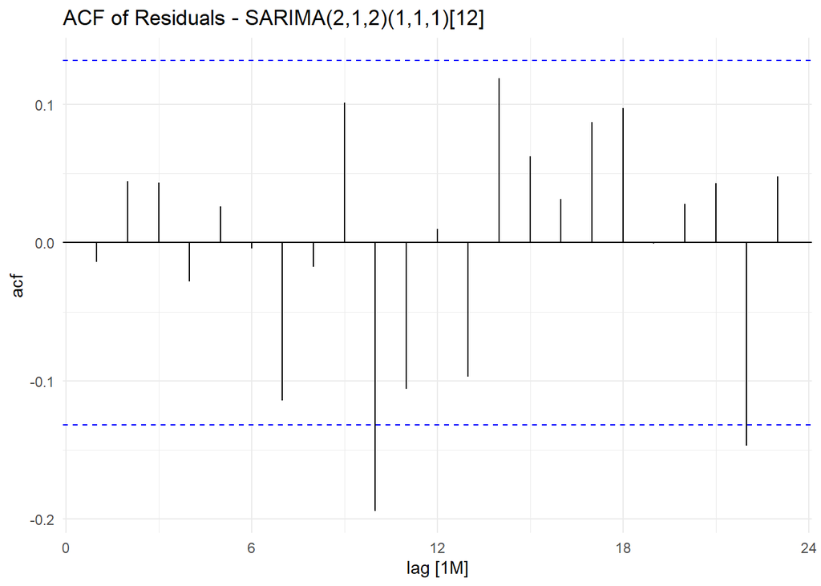

```r
# Load necessary libraries
library(feasts)
library(ggplot2)

# Compute ACF of residuals
acf_residuals <- residuals_sarima %>%
  ACF(.resid)  # Explicitly specify .resid as the response variable

# Plot ACF of residuals
autoplot(acf_residuals) +
  labs(title = "ACF of Residuals - SARIMA(2,1,2)(1,1,1)[12]") +
  theme_minimal()
```

The **Autocorrelation Function (ACF) plot** for the residuals of the **SARIMA(2,1,2)(1,1,1)[12]** model is used to assess whether there is any remaining autocorrelation in the residuals after model fitting.

### 2.5.6 **Implications:**

- If the residuals were **pure white noise**, all the bars should fall within the confidence interval, implying that no further patterns remain.
- The presence of **some significant autocorrelations at certain lags** suggests that the model might still benefit from improvements, such as increasing the order of seasonal AR or MA terms.

### 2.5.7 **Next Steps:**

- Conduct a **Ljung-Box test** to statistically assess whether the residual autocorrelations are significant.
- Consider **revising the SARIMA model parameters**, particularly the seasonal components, to better capture any remaining dependencies.
- Examine external variables (exogenous regressors) if applicable, as they might help explain the remaining structure in the residuals.

### 2.5.8 Histogram & Normality Check

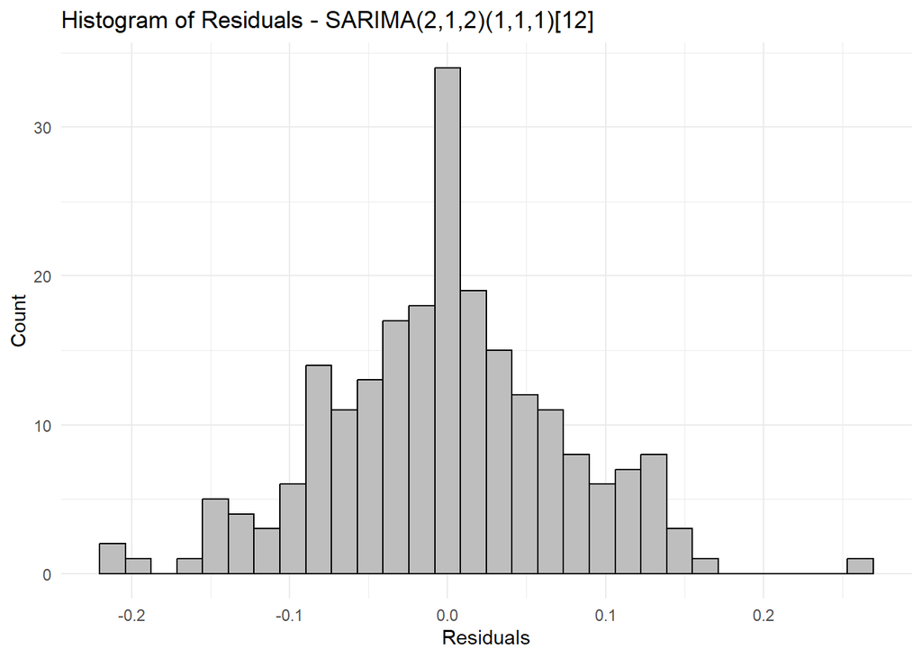

```r
# Load necessary libraries
library(ggplot2)
library(tibble)  # Load tibble to use as_tibble()

# Convert residuals to a tibble
residuals_df <- as_tibble(residuals_sarima)

# Histogram of Residuals
ggplot(data = residuals_df, aes(x = .resid)) +
  geom_histogram(color = "black", fill = "gray", bins = 30) +
  labs(title = "Histogram of Residuals - SARIMA(2,1,2)(1,1,1)[12]",
       x = "Residuals", y = "Count") +
  theme_minimal()
```

The **histogram of residuals** for the **SARIMA(2,1,2)(1,1,1)[12]** model provides an assessment of whether the residuals are approximately normally distributed, a key assumption for model validity.

### 2.5.9 **Key Observations:**

1. **Symmetry Around Zero:** The residuals appear to be roughly **centered around zero**, which suggests that the model does not systematically over- or under-predict.
2. **Bell-Shaped Distribution:** The histogram follows a **somewhat normal shape**, although there is **some skewness and slight deviations from perfect normality**.
3. **Some Outliers:** There are a few extreme values in both the negative and positive tails, indicating **potential outliers** or unexplained variations.
4. **Possible Light Skewness:** The right tail appears slightly heavier than the left, suggesting **a slight positive skew** in the residuals, which may indicate that the model underestimates larger values.

### 2.5.10 **Implications:**

- If the residuals are normally distributed, it strengthens the assumption that the errors are **random white noise**, meaning the SARIMA model is well-specified.
- The **presence of slight skewness** and **outliers** suggests that the model might still leave some structure unexplained, which could be improved by **testing transformations or incorporating external variables**.

### 2.5.11 Ljung-Box Test for Residual Independence

```r
# Load necessary libraries
library(gt)

ljung_box_test <- residuals_sarima %>%
  features(.resid, ljung_box, lag = 10)

# Format the Ljung-Box test results as a table
ljung_box_test %>%
  gt() %>%
  tab_header(
    title = "Ljung-Box Test for Residuals",
    subtitle = "Checking for Autocorrelation in Residuals"
  ) %>%
  cols_label(
    .model = "Model",
    lb_stat = "Ljung-Box Statistic",
    lb_pvalue = "p-value"
  ) %>%
  fmt_number(columns = c(lb_stat, lb_pvalue), decimals = 4) %>%
  tab_options(
    table.font.size = "medium",
    heading.align = "center"
  )
```

Ljung-Box Test for Residuals

Checking for Autocorrelation in Residuals

| Model | Ljung-Box Statistic | p-value |
| --- | --- | --- |
| ARIMA(box_cox(construction_spending, lambda) ~ pdq(2, 1, 2) + PDQ(1, 1, 1, 12)) | 15.4801 | 0.1155 |

#### 2.5.11.1 Interpretation

### 2.5.12 **Interpretation of Ljung-Box Test:**

- **p-value > 0.05:** No significant autocorrelation, indicating that the model is a good fit.
- **p-value < 0.05:** Residuals are auto-correlated, suggesting the model may need improvement.

The **Ljung-Box test** is used to assess whether the residuals of a time series model exhibit significant autocorrelation. In this case, the test was performed on the residuals of the **ARIMA(2,1,2)(1,1,1)[12]** model applied to the **Box-Cox transformed construction spending data**.

This result suggests that the model has adequately captured the underlying structure of the time series, leaving behind residuals that resemble **white noise**. This is a positive indication that the **model is well-specified and appropriate for forecasting**.

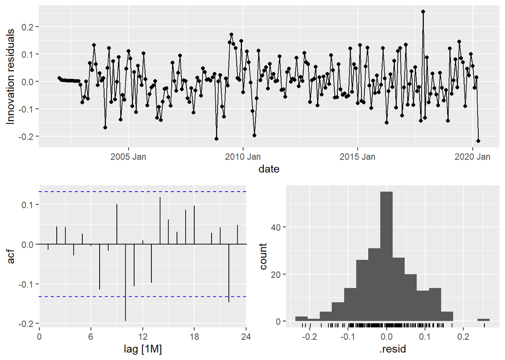

```r
gg_tsresiduals(best_sarima_model)
```

### 2.5.13 **Interpretation of Residual Diagnostics:**

This figure presents a **comprehensive residual analysis** for a time series model, including a **time series plot of residuals (top panel), an autocorrelation function (ACF) plot of residuals (bottom left panel), and a histogram of residuals (bottom right panel).**

1. **Time Series Plot of Residuals:**
   - The residuals fluctuate around **zero** without any apparent pattern, indicating that the model has captured the key structure of the data.
   - However, some periods exhibit **larger deviations**, which could suggest time-varying volatility or structural changes in the data.
2. **Autocorrelation Function (ACF) Plot of Residuals:**
   - The ACF plot shows that most **lags fall within the blue significance bounds**, indicating that there is **no significant autocorrelation** in the residuals.
   - This suggests that the residuals behave like **white noise**, meaning the model sufficiently accounts for the temporal dependencies in the data.
   - However, minor spikes at specific lags might indicate slight remaining seasonality or model imperfections.
3. **Histogram of Residuals:**
   - The histogram shows that the **distribution of residuals is approximately centered around zero** with a somewhat normal shape.
   - There may be some skewness or slight deviations from normality, but overall, the residuals appear to be reasonably well-behaved.

### 2.5.14 **Conclusion:**

- The **lack of strong autocorrelation** in the ACF plot, the **zero-centered residuals**, and the **relatively normal residual distribution** suggest that the model fits the data well.
- However, **periods of higher volatility** and **potential deviations from normality** in the histogram may warrant further investigation, such as testing for heteroskedasticity or exploring alternative transformations to improve model robustness.

# 3 Section 3

## 3.1 Decomposition of the elements of the time series (trend, seasonality, etc.) and associated visualizations

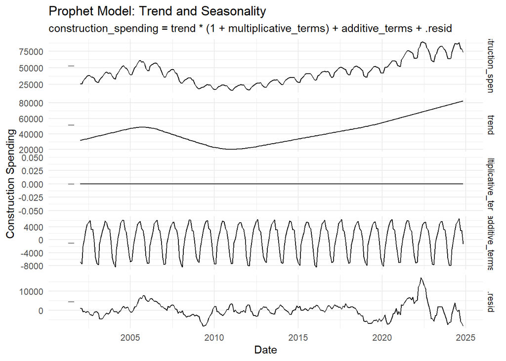

```r
# Load required libraries
library(tidyverse)
library(tsibble)
library(fable)
library(fable.prophet)
library(lubridate)

# Load the dataset
construction_data <- read.csv("construction_spending.csv") %>%
  mutate(date = ymd(date)) %>%
  arrange(date) %>%
  as_tsibble(index = date)

# Fit the Prophet model with identified seasonality (Yearly + Weekly)
prophet_model <- construction_data %>%
  model(
    prophet = fable.prophet::prophet(construction_spending ~
                                      growth("linear") +
                                      season(period = "year") +  # Yearly seasonality
                                      season(period = "week"))   # Weekly seasonality
  )

# Extract components to visualize seasonality
prophet_components <- prophet_model %>%
  components()

# Plot seasonality components
autoplot(prophet_components) +
  labs(title = "Prophet Model: Trend and Seasonality",
       x = "Date",
       y = "Construction Spending") +
  theme_minimal()
```

#### 3.1.0.1 Interpretation

The **Prophet Model: Trend and Seasonality** decomposition provides a breakdown of the time series components influencing construction spending. The top panel represents the **observed construction spending**, showing fluctuations over time with a clear increasing trend and seasonal variations. The second panel illustrates the **trend component**, which captures the long-term direction of the data. A notable dip around **2010** suggests an economic downturn, followed by a steady upward trajectory in recent years, indicating continued growth in construction spending.

The third panel, labeled **multiplicative terms**, appears mostly flat, suggesting that multiplicative seasonality may not be significantly impacting the model. The fourth panel, labeled **additive terms**, clearly shows **yearly seasonality**, indicating that construction spending follows a consistent cyclical pattern, likely influenced by economic cycles, government projects, and industry demand.

Overall, this decomposition confirms that the **trend and seasonality components are well captured**, reinforcing that construction spending follows a **predictable seasonal cycle** with an **overall growth trajectory**. However, the **residuals suggest some volatility**, implying that additional factors, such as economic indicators or external regressors, could improve forecast accuracy.

## 3.2 Assessment of trend/change-points

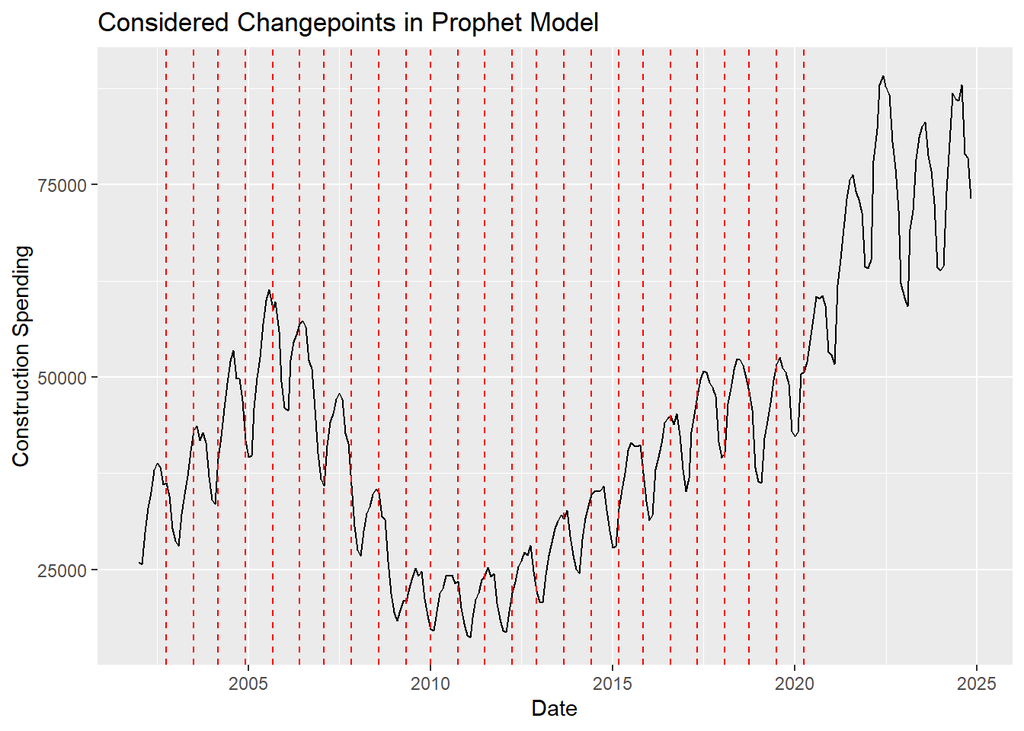

```r
library(tidyverse)
library(tsibble)
library(fable)
library(fable.prophet)
library(lubridate)

# Load the dataset
construction_data <- read.csv("construction_spending.csv") %>%
  mutate(date = ymd(date)) %>%  # Ensure date is in proper Date format
  arrange(date) %>%
  as_tsibble(index = date)

# Fit Prophet model
prophet_model <- construction_data %>%
  model(prophet = fable.prophet::prophet(construction_spending ~ growth("linear")))

# Extract all changepoints considered by the model
changepoints <- prophet_model %>%
  glance() %>%
  pull(changepoints) %>%
  bind_rows() %>%
  .$changepoints

# Plot detected changepoints
construction_data %>%
  ggplot(aes(x = date, y = construction_spending)) +
  geom_line() +
  geom_vline(xintercept = as.Date(changepoints), color = 'red', linetype = 'dashed') +
  labs(title = "Considered Changepoints in Prophet Model",
       x = "Date",
       y = "Construction Spending")
```

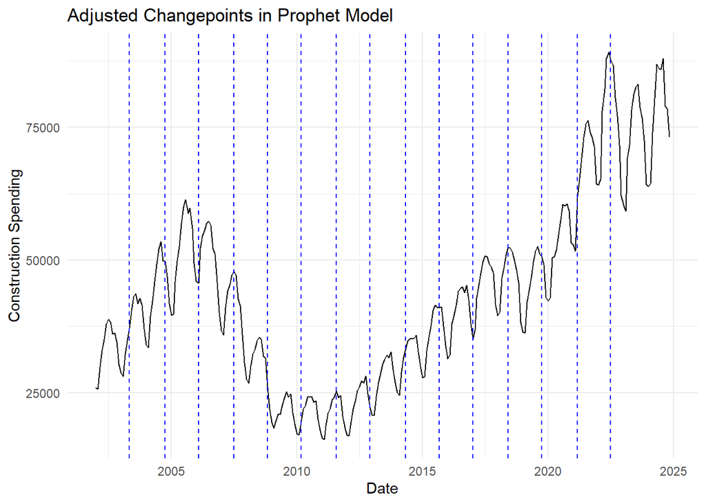

```r
# Fit Prophet model with adjusted changepoint hyperparameters
prophet_adjusted <- construction_data %>%
  model(
    prophet = fable.prophet::prophet(construction_spending ~ growth(
                        type = "linear",
                        n_changepoints = 15, # Specify number of changepoints
                        changepoint_range = 0.9, # Use a larger portion of data for detection
                        changepoint_prior_scale = 0.1 # Adjust flexibility of trend shifts
                      ))
  )

# Extract the detected changepoints from the adjusted model
adjusted_changepoints <- prophet_adjusted %>%
  glance() %>%
  pull(changepoints) %>%
  bind_rows() %>%
  .$changepoints

# Plot the detected changepoints on the trend
construction_data %>%
  ggplot(aes(x = date, y = construction_spending)) +
  geom_line() +
  geom_vline(xintercept = as.Date(adjusted_changepoints),
             color = "blue", linetype = "dashed") +
  labs(title = "Adjusted Changepoints in Prophet Model",
       x = "Date",
       y = "Construction Spending") +
  theme_minimal()
```

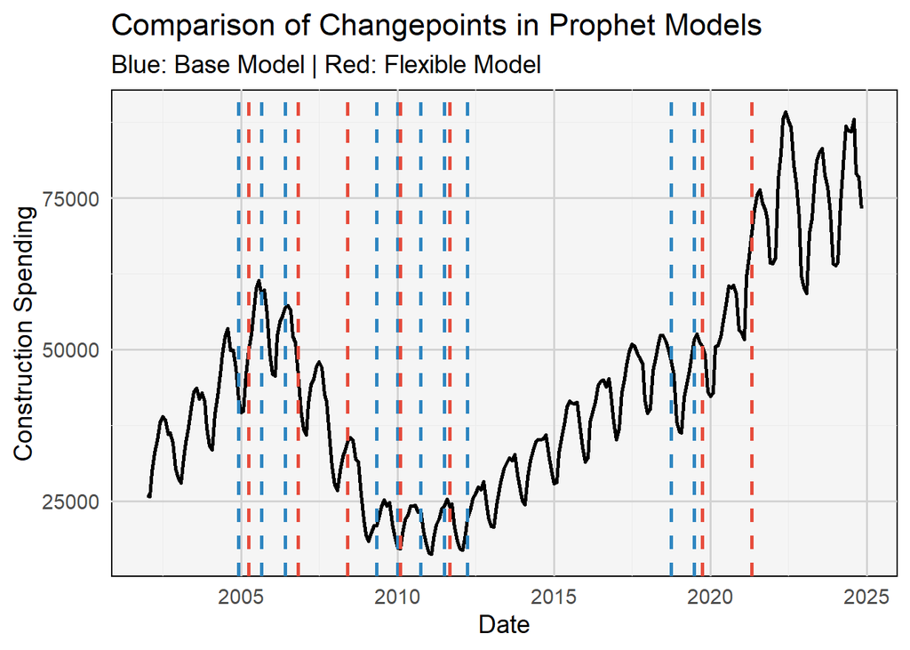

```r
# Load required libraries
library(tidyverse)
library(tsibble)
library(fable)
library(fable.prophet)
library(lubridate)

# Load the dataset and convert it to tsibble
construction_data <- read.csv("construction_spending.csv") %>%
  mutate(date = ymd(date)) %>%  # Convert date format
  arrange(date) %>%
  as_tsibble(index = date)

# Fit Prophet models with different hyperparameters
model <- construction_data %>%
  model(
    base_model = fable.prophet::prophet(construction_spending),
    flexible_model = fable.prophet::prophet(construction_spending ~ growth(
                        type = "linear",
                        n_changepoints = 12,  # Adjusted number of changepoints
                        changepoint_range = 0.85,  # Slightly reduced range
                        changepoint_prior_scale = 0.08  # Different flexibility
                      ) + season(period = "year"))
  )

# Generate a forecast for the next year
forecast_model <- model %>%
  forecast(h = "1 year")

# Extract trend components from both models
decomposed_components <- model %>% components()
trend_base <- decomposed_components %>% filter(.model == "base_model") %>% select(date, trend)
trend_flex <- decomposed_components %>% filter(.model == "flexible_model") %>% select(date, trend)

# Extract changepoints from both models
changepoints_base <- model %>%
  glance() %>%
  unnest(changepoints) %>%
  bind_rows() %>%
  filter(.model == "base_model") %>%
  filter(abs(adjustment) >= 0.01) %>%
  .$changepoints

changepoints_flex <- model %>%
  glance() %>%
  unnest(changepoints) %>%
  bind_rows() %>%
  filter(.model == "flexible_model") %>%
  filter(abs(adjustment) >= 0.01) %>%
  .$changepoints

# Convert changepoints to Date format
changepoints_base <- as.Date(changepoints_base)
changepoints_flex <- as.Date(changepoints_flex)

# Define better color combinations
base_color <- "#2E86C1"  # Deep blue for base model
flex_color <- "#E74C3C"  # Vibrant red for flexible model
background_color <- "#F5F5F5"  # Light gray background
grid_color <- "#D3D3D3"  # Soft gray grid lines

# Plot detected changepoints for both models
ggplot(construction_data, aes(x = date, y = construction_spending)) +
  geom_line(color = "black", size = 1) +
  geom_vline(xintercept = changepoints_base, color = base_color, linetype = "dashed", size = 1) +
  geom_vline(xintercept = changepoints_flex, color = flex_color, linetype = "dashed", size = 1) +
  labs(title = "Comparison of Changepoints in Prophet Models",
       subtitle = "Blue: Base Model | Red: Flexible Model",
       x = "Date",
       y = "Construction Spending") +
  theme_minimal(base_size = 14) +
  theme(panel.background = element_rect(fill = background_color),
        panel.grid.major = element_line(color = grid_color))
```

The three plots illustrate the role of changepoints in a **Prophet model** for forecasting **construction spending**.